# MATH-156 - Week 14 - Inference for Two-Sample Quantitative Data

**Directions**:

- For this activity, I’d like you record your responses in a word doc or a shared google doc
  - If you need to re-download the data-explorer app, you can find it here: https://remiller1450.github.io/m156f20/app_setup.html
- On certain questions you will be asked to include screenshots
  - On Windows PCs, you can use the snipping tool app (start typing “snipping tool” into the Windows search bar)
  - On Mac PCs, there are several ways to take a screenshot: https://www.cleverfiles.com/howto/snipping-tool-mac.html
- On Canvas you may submit either your answer document itself, or a link to the google doc (make sure I have permission to view it)
  - Your score will be mostly based upon effort, and it’s okay if you don’t finish. But recognize that these questions are excellent practice for the upcoming exam.

## Introduction

This week we saw how to use the $t$-distribution as the basis for statistical inference comparing the means of two groups. More specifically, we based this inference off of the result:

$$\bar{x}_1 - \bar{x}_2 \sim N\bigg(\mu_1 - \mu_2, \sqrt{\tfrac{\sigma_1^2}{n_1} + \tfrac{\sigma_2^2}{n_2}}\bigg)$$
The extra uncertainty introduced by estimating $\sigma_1$ and $\sigma_2$ (using the sample standard deviations $s_1$ and $s_2$) necessitates the use of the $t$-distribution (thereby motivating the two-sample $t$-test).

In today’s activity, we’ll practice using the two-sample $t$-test. We’ll also practice dealing with the decision making inherent to using statistical tests to answer questions about data, so you should be prepared to apply statistical methods we’ve previously learned about.

$~$

## Application #1 - Sleep Deprivation (revisited)

Previously, we looked at data from a research study that explored sleep deprivation and cognitive ability. Provided below is a description of the study:

It is well-established that sleep deprivation has a detrimental cognitive effects. But do these effects linger, or can a person “make up” for sleep deprivation by getting a full night’s sleep for consecutive days?

An article published in *Nature* ([Stickgold, James, and Hobson, 2000](https://www.nature.com/articles/nn1200_1237)) had 11 volunteers, aged 18 to 25, perform a visual discrimination task on two separate occasions. The first task was performed immediately following a night of deprived sleep, and the second task was performed after two nights where the participants could sleep as much they wanted.

In each task, subjects were repeatedly shown screens containing a *fixation letter* (either T or L) and *three bars* (either oriented horizontally or vertically) in a random configuration (sometimes the letter was T/L and sometimes the bars were horizontal/vertical). The researchers recorded the time it took each subject to correctly identify the fixation letter and the orientation of the bars. In between each screen, a masking screen was flashed.

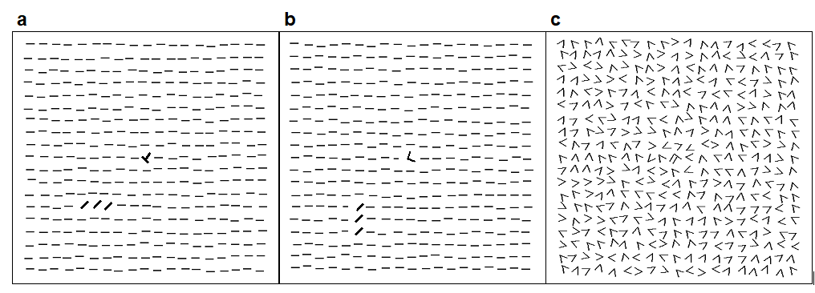

The figure above illustrates two possible *target screens* (a) and (b), as well as a *masking screen* (c). In target screen (a), a correct response would be “T” and “horizontal”; while in target screen (b), a correct response would be L and “vertical”, The masking screen (c) would briefly appear between randomized target screens.

Each subject saw 1250 randomly determined trial screens (in blocks of 25) on each repeat of the test (after a night of sleep deprivation, then after two nights of full sleep). The differences in performance (measured by the change in average response time in milliseconds) for each subject are shown below, with positive values indicating faster responses the second time they took the test.

| Subject | Improvement |
| --- | --- |
| 1 | -14.7 |
| 2 | -10.7 |
| 3 | -10.6 |
| 4 | 2.2 |
| 5 | 2.4 |
| 6 | 4.5 |
| 7 | 7.2 |
| 8 | 9.6 |
| 9 | 10.0 |
| 10 | 21.3 |
| 11 | 21.8 |

The boxplot below displays the distribution of these 11 data-points, with the mean improvement denoted by the “X”:

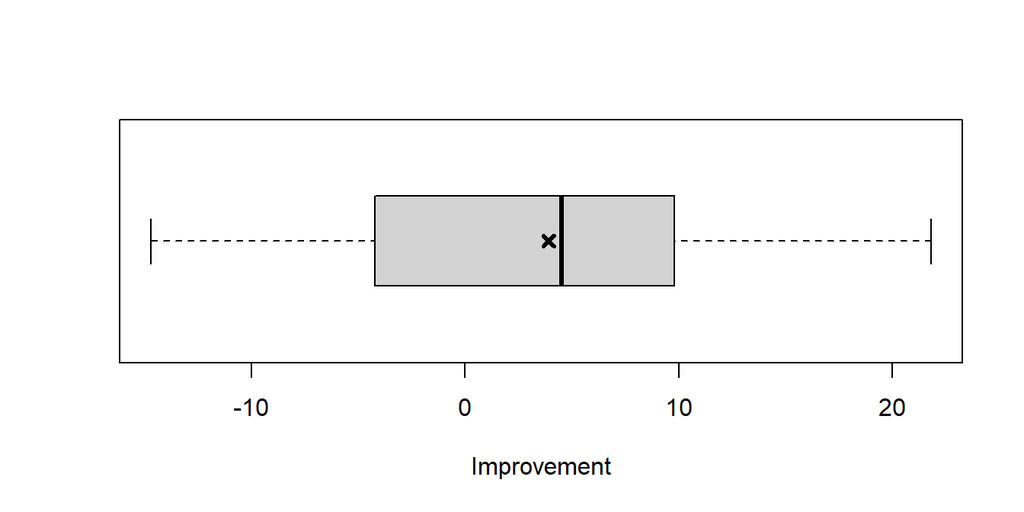

**Question #1**: The boxplot above shows that the average subject’s score tended to improve after receiving two full nights of sleep and retaking the test. However, could this improvement be due to the experimental design? Briefly explain.

$~$

### Statistical Inference

A major weakness of our analysis of these data is that it ignores the possibility that improvements are due to subjects taking the test for the second time, thereby making it more familiar and less challenging. The researchers in the real study anticipated this, and used a *control group* containing 10 subjects (who did both the first and second tasks without sleep deprivation). The boxplots below illustrate the results in these two groups:

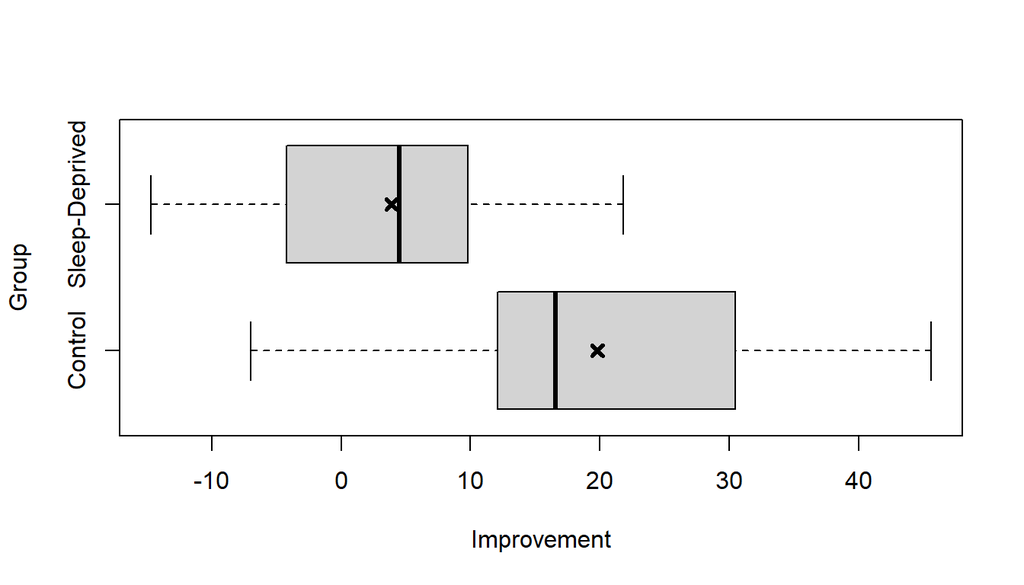

The sleep-deprived group saw a mean improvement of 3.91 ms, with a standard deviation of 12.2, while the control group saw a mean improvement of 19.82 ms, with a standard deviation of 14.7.

**Question #2**: Based upon what you know about these data, briefly explain why the conditions are met to use a two-sample t-test to compare the mean improvement in the sleep-deprived and control groups.

**Question #3**: Compare the mean improvement in each group using a two-sample t-test. You may assume that $df = 17.5$. Be sure to include the following steps in your write-up:

1. State the null hypothesis in both words and statistical symbols
2. Show how you calculated the $T$-value
3. Provide the $p$-value
4. Provide a one-sentence conclusion *in the context of this application*

$~$

## Application #2 - Infant Heart Surgery

Some infants are born with congenital heart defects that require surgery shortly after birth. The standard surgical approach is known as “circulatory arrest”, and has the downside of cutting of the flow of blood to the brain during the surgery, potentially leading to brain damage. An alternative surgical approach is “low-flow bypass”, which maintains circulation to the brain, but does so with an external pump that might lead to other types of brain injuries. The goal of this study is to determine which surgical approach yields better developmental outcomes for infants born with congenial heart defects.

The Infant Heart Surgery dataset contains data from a randomized experiment conducted by surgeons at Harvard Medical School. The data document the outcomes of 70 infants who received low-flow bypass surgery, and 73 infants who received surgery under a circulatory arrest approach. The study considered two primary outcomes:

- **Psychomotor Development Index (PDI)** - a composite score measuring physiological development, with higher scores indicating greater development
- **Mental Development Index (MDI)** - a composite score measuring mental development, with higher scores indicating greater development

*Note*: we previously looked at this study in Week 4.

**Question #1**: Briefly critique the design of this study. That is, how concerned are you that sampling, confounding, and/or bias might unfairly influence the relationship between type of surgery and PDI/MDI seen in this study?

$~$

### Statistical Inference

**Question #2**: Download the Infant Heart Surgery dataset [at this link](https://remiller1450.github.io/data/InfantHeart.csv), then use [this StatKey page](https://www.lock5stat.com/StatKey/descriptive_1_quant_1_cat/descriptive_1_quant_1_cat.html) to calculate the descriptive statistics needed for statistical inference on the variable PDI (highlight the first two columns and copy-paste them into the “edit data” section of StatKey). Add a screenshot of the “Summary Statistics” table to your write-up.

**Question #3**: Using the descriptive statistics calculated in Question #2, construct a 95% confidence interval estimate for the mean difference in PDI (low-flow minus circulatory arrest). You may assume there are 71.2 degrees of freedom in this scenario.

**Question #4**: Based upon the confidence interval you constructed in Question #3, is there a *statistically significant* difference (at the $\alpha = 0.05$ significance level) in mean PDI scores between these two surgeries? Is there a *clinically significant* difference? Briefly explain.

$~$

## Application #3 - Home Court Advantage (or disadvantage?)

It is widely recognized that sports teams have an advantage when playing on their home court. Some popular explanations for this advantage involve the home crowd influencing the performance of the players, or the calls made by the referees.

During the 2018-19 NBA season, the Sacramento Kings won 13 home games and lost 16 when they had a sell-out crowd, compared to 11 home wins and 1 loss when they had a smaller crowd.

**Question #1**: What are the explanatory and response variable in these data? Is each variable categorical or quantitative?

**Question #2**: Is this an observational or experimental study? How might that influence your conclusions regarding the relationship between the explanatory and response variables you identified in Question #1?

$~$

### Statistical Inference

**Question #3**: Use a statistical test to determine whether there is a statistically significant association between the variables you identified in Question #1. In your lab write-up, be sure to include the following steps:

1. State the null hypothesis in both words and statistical symbols
2. Calculate an appropriate Z or T value
3. Provide the corresponding $p$-value
4. Provide a one-sentence conclusion *in the context of this application*

**Question #4**: Comment on whether assumptions were met for the statistical test you used in Question #3.

$~$

### Conclusion

**Question #5**: The statistical test in Question #3 provides compelling statistical evidence that the Kings being more likely to lose when there is a sellout crowd is not likely due to random chance. But does this statistical finding imply that smaller crowds cause the Kings to play better? Briefly explain.

$~$